# Assessment I- Dow Jones Panel

FIRE 540: Financial Analytics

Author

Affiliation

Larry Tentor

Virginia Commonwealth University

# Student Name

Priti Jain

## Academic Integrity Statement

*I, Priti Jain, hereby state that I have not communicated with or gained information in any way from my classmates or anyone other than the Professor or TA during this test, and that all work is my own.*

## Getting help

You are not allowed to post any questions on the public community repo or the public questions channel on Slack. Any questions about the test must be asked in e-mails to faculty.

**A note on sharing / reusing code:** I am well aware that a huge volume of code is available on the web to solve any number of problems. For this test you are allowed to make use of any online resources (e.g. StackOverflow) but you must explicitly cite where you obtained any code you directly use (or use as inspiration). You are also **not** allowed to ask a question on an external forum, you can only use answers to questions that have already been answered. Any recycled code that is discovered and is not explicitly cited will be treated as plagiarism. All communication with classmates is explicitly forbidden.

## Test Guidlines

1. Please use R and the modern tidyverse functions to solve the below challenges. Please replace the **STUDENT RESPONSE REQUIRED** with complete sentences answers. Students are not to look at or share others code or approaches. All submitted work shall represent the student’s own thoughts and typing. Students may be asked to explain their answer.
2. Your solutions must be written up in the Quarto Markdown (qmd) file. This file must include your code and any text answers for each task. Your “submission” will be the rendered HTML output that you submit to Canvas.
3. This is open book, open internet, closed other people. You may use any online or book based resource you would like, but you must include citations for any code that you use (directly or indirectly). You **may not** consult with anyone else about this test other than the Professor or TA for this course. You cannot ask direct questions on the internet, or consult with each other, not even for hypothetical questions.
4. The test due date is established via Canvas.
5. Each question requires a (brief) narrative and possible description of your approach. You can use comments in your code, but do not extensively count on these. I should be able to suppress **all** the code in your document and still be able to read and make sense of your answers. See the first setup code chunk in your qmd file to experiment with suppressing and revealing your code.
6. Even if the answer seems obvious from the R output, make sure to state it in your narrative as well. For example, if the question is asking what is 2 + 2, and you have calculated and output 4. You should additionally have a sentence that states “The answer to the question is four (4).”

Functions that might be helpful are listed in Table 1.

Table 1: Useful Functions

| Meta Data | Review Data Frame | Vector Calculation | Tidyverse |
| --- | --- | --- | --- |
| `class(◉)` | `head(◉)` | `min(◉)` | `select(◉)` |
| `typeof(◉)` | `tail(◉)` | `max(◉)` | `filter(◉)` |
| `nrow(◉)` | `glimpse(◉)` | `mean(◉)` | `arrange(◉)` |
| `ncol(◉)` | `skimr::skim(◉)` | `sum(◉)` | `mutate(◉)` |
|  |  | `prod(◉)` | `group_by(◉)` |
|  |  | `cor(◉)` | `summerize(◉)` |
|  |  | `sd(◉)` |  |
|  |  | `cumsum(◉)` |  |
|  |  | `cumprod(◉)` |  |

Help on a function can be obtained by selection the console tab and typing `?` or `??` before the function name.

## Dow Jones Panel Data Import

This test’s data contains a panel of securities over time that are the constituents of the Dow Jones Industrial Average. [Index Methodogy](https://www.spglobal.com/spdji/en/documents/methodologies/methodology-index-math.pdf) Reference.

**Import Settings**

```r
columnName <- c( 'DateEffective', 'CodeIndex', 'NameIndex', 'TickerIndex'
               , 'SecCodeDJ', 'SecCodeX', 'Name', 'NameX'
               , 'TickerSecurity', 'CUSIP', 'Weight', 'BeginValue'
               , 'Contribution', 'Code', 'Open_', 'High'
               , 'Low', 'Close_', 'TotalReturnIndex'
               )
columnType <- cols( DateEffective    = col_date(format = '%Y-%m-%d')
                  , CodeIndex        = col_factor()
                  , NameIndex        = col_factor()
                  , TickerIndex      = col_factor()
                  , SecCodeDJ        = col_integer()
                  , SecCodeX         = col_integer()
                  , Name             = col_character()
                  , NameX            = col_character()
                  , TickerSecurity   = col_character()
                  , CUSIP            = col_character()
                  , Weight           = col_number()
                  , BeginValue       = col_number()
                  , Contribution     = col_number()
                  , Code             = col_integer()
                  , Open_            = col_double()
                  , High             = col_double()
                  , Low              = col_double()
                  , Close_           = col_double()
                  , TotalReturnIndex = col_number()
                  )
width     <-    c( 14, 12, 61, 31
                 , 12, 12, 61, 62
                 , 15,  9, 23, 23
                 , 23, 12, 14, 14
                 , 14, 14, 8 )
fileName   <- paste0(here(), '/course-material/_data/dj-panel.rpt')
```

**Access dataset `DJ Panel`**

```r
DJ_panel <- read_fwf( fileName
                    , skip = 1
                    , col_types     = columnType
                    , col_positions = fwf_widths( width, columnName )
                    , na            = c('NULL')
                    )
read_issues <- problems(DJ_panel)
```

## Questions

### Question 1

A. **(8 points)** - Data Profile: How many Indexes are covered in this file and what are there names? In code, please display the unique triple (CodeIndex, NameIndex, TickerIndex) and the number of rows associated across the entire data set. Please sort display by `NameIndex`.

**Question 01A, Student**

```r
DJ_panel %>%
  count(CodeIndex, NameIndex, TickerIndex, sort = FALSE) %>%
  arrange(NameIndex) %>%
  gt()
```

| CodeIndex | NameIndex | TickerIndex | n |
| --- | --- | --- | --- |
| 314 | DOW JONES INDUSTRIAL AVERAGE INDEX | DJX_IDX | 1887 |

**Analysis follow up:** How many different indices are covered within this data set?

B. **(8 points)** - Data Profile: In code using tidyverse, please display the earliest `DateEffective` and latest `DateEffective` within the data set, including the security count and the sum of the weights?

**Question 01B, Student**

```r
DJ_panel %>%
  filter(DateEffective %in% range(DateEffective, na.rm = TRUE)) %>%
  group_by(period = if_else(DateEffective == min(DateEffective), "Earliest Date", "Latest Date")) %>%
  summarise(DateEffective = first(DateEffective),
            security_count = n(),
            total_weight = sum(Weight, na.rm = TRUE),
            .groups = "drop")%>%
  gt()
```

| period | DateEffective | security_count | total_weight |
| --- | --- | --- | --- |
| Earliest Date | 2013-12-31 | 30 | 100 |
| Latest Date | 2018-12-31 | 32 | 100 |

**Analysis follow up:** How many securities are present on the the first date? What is the sum of the weight column for this day?

There are 30 securities present in first date i.e 2013-12-31 and the weight is 100.

C. **(8 points)** - Data Profile: In code, please display the count of securities reported on a date and the number of dates in the file that have the same number of securities within the dataset. Also in code, display the first `DateEffective` (and counts) on which the minimum and maximum number of securities are reported.

Output should have the form (or structure) of (values are **not** representative)

Example structure of answer 1C

| Count of securities reported on a date | Count of dates that have this same count |
| --- | --- |
| 25 | 16 |
| 27 | 12 |

**Question 01C, Student**

```r
sec_count <- DJ_panel %>% count(DateEffective)

sec_count %>%
  count(`Count of securities reported on a date` = n,
        name = "Count of dates that have this same count") %>%
  gt()
```

| Count of securities reported on a date | Count of dates that have this same count |
| --- | --- |
| 30 | 11 |
| 31 | 43 |
| 32 | 7 |

**Question 01C, Student**

```r
sec_count %>%
  filter(n %in% range(n)) %>%
  slice_min(DateEffective, by = n) %>%
  gt()
```

| DateEffective | n |
| --- | --- |
| 2013-12-31 | 30 |
| 2018-06-29 | 32 |

**Analysis follow up:** Does the sum of the count of dates with the same number of securities, represent all the dates in the file? And how do you know?

Yes, the sum of the count of dates with the same number of securities does represent all the dates in the file. This is because we first group the data by each DateEffective to count how many securities were reported per date, and then group those counts to see how many dates had each specific count. When we sum the number of dates across all these groups, we are essentially totaling all the unique reporting dates in the dataset.

D. **(8 points)** - Data Profile: In code, what is the sum of weights for each date also include the maximum and minimum security weight by date (excluding NA’s)? ? Display the most recent year.

**Question 01D, Student**

```r
DJ_panel %>%
  filter(!is.na(Weight)) %>%
  mutate(Year = year(DateEffective)) %>%
  group_by(DateEffective) %>%
  summarise(
    total_weight = sum(Weight),
    max_weight = max(Weight),
    min_weight = min(Weight),
    Year = first(Year),
    .groups = "drop"
  ) %>%
  filter(Year == max(Year)) %>%
  arrange(desc(DateEffective)) %>% gt()
```

| DateEffective | total_weight | max_weight | min_weight | Year |
| --- | --- | --- | --- | --- |
| 2018-12-31 | 100 | 7.718781 | 0 | 2018 |
| 2018-11-30 | 100 | 7.718781 | 0 | 2018 |
| 2018-10-31 | 100 | 7.718781 | 0 | 2018 |
| 2018-09-28 | 100 | 7.718781 | 0 | 2018 |
| 2018-08-31 | 100 | 7.718781 | 0 | 2018 |
| 2018-07-31 | 100 | 7.718781 | 0 | 2018 |
| 2018-06-29 | 100 | 7.718781 | 0 | 2018 |
| 2018-05-31 | 100 | 7.848065 | 0 | 2018 |
| 2018-04-30 | 100 | 7.848065 | 0 | 2018 |
| 2018-03-30 | 100 | 7.848065 | 0 | 2018 |
| 2018-02-28 | 100 | 7.848065 | 0 | 2018 |
| 2018-01-31 | 100 | 7.848065 | 0 | 2018 |

**Analysis follow up:** For the most recent date, what company has the largest dollars invested in the index?

On the most recent date in the dataset, 2018-12-31, the company with the largest allocation in the Dow Jones Index was Boeing, holding a weight of approximately 7.72%. This indicates that Boeing represented the largest share of the index by value at that time.

```r
DJ_panel %>%
  filter(DateEffective == max(DateEffective, na.rm = TRUE)) %>%
  filter(Weight == max(Weight, na.rm = TRUE)) %>%
  select(DateEffective, Name, Weight) %>% gt()
```

| DateEffective | Name | Weight |
| --- | --- | --- |
| 2018-12-31 | BOEING | 7.718781 |

E. **(8 points)** - Data Profile: In code, identify any dates and securities that have NA’s within the pricing fields (Open_, High, Low, Close_)? Display up to ten (10) example records with the fields `DateEffective`, `Name`, `TickerSecurity`, `Open_`, `High`, `Low`, `Close_`, `TotalReturnIndex`.

**Question 01E, Student**

```r
DJ_panel %>%
  filter(is.na(Open_) | is.na(High) | is.na(Low) | is.na(Close_)) %>%
  select(DateEffective, Name, TickerSecurity, Open_, High, Low, Close_, TotalReturnIndex) %>%
  slice_head(n = 10) %>% gt()
```

| DateEffective | Name | TickerSecurity | Open_ | High | Low | Close_ | TotalReturnIndex |
| --- | --- | --- | --- | --- | --- | --- | --- |
| 2018-03-30 | APPLE | AAPL | NA | NA | NA | NA | NA |
| 2018-03-30 | AMERICAN EXPRESS | AXP | NA | NA | NA | NA | NA |
| 2018-03-30 | BOEING | BA | NA | NA | NA | NA | NA |
| 2018-03-30 | CATERPILLAR | CAT | NA | NA | NA | NA | NA |
| 2018-03-30 | CISCO SYSTEMS | CSCO | NA | NA | NA | NA | NA |
| 2018-03-30 | CHEVRON | CVX | NA | NA | NA | NA | NA |
| 2018-03-30 | WALT DISNEY | DIS | NA | NA | NA | NA | NA |
| 2018-03-30 | DOWDUPONT | DWDP | NA | NA | NA | NA | NA |
| 2018-03-30 | GENERAL ELECTRIC | GE | NA | NA | NA | NA | NA |
| 2018-03-30 | GOLDMAN SACHS GP. | GS | NA | NA | NA | NA | NA |

**Analysis follow up:** List the dates that have any NA’s within the pricing data?

The date that has any NA’s within the pricing data is: 2018-03-30

### Question 2

2. **(15 points)** - For WALT DISNEY (DIS), What is the (closing) price return from `2018-04-30` til `2018-09-28`, round this value to six decimal digits? What is the return based on the TotalReturnIndex field? Display both of these calculated results. (See function round() by using help ?round)

**Question 02, Student**

```r
DJ_panel %>%
  filter(TickerSecurity == "DIS", DateEffective %in% as.Date(c("2018-04-30", "2018-09-28"))) %>%
  arrange(DateEffective) %>%
  summarise(
    Price_Return = round((Close_[2] - Close_[1]) / Close_[1], 6),
    Total_Return = round((TotalReturnIndex[2] - TotalReturnIndex[1]) / TotalReturnIndex[1], 6)) %>%
    gt() %>% tab_header(
    title = "Disney: Price and Total Return (Apr 30 - Sep 28, 2018)")
```

Disney: Price and Total Return (Apr 30 - Sep 28, 2018)

| Price_Return | Total_Return |
| --- | --- |
| 0.165554 | 0.174898 |

**Analysis follow up:** Do these calculated returns match (to six decimal places) for using either closing price or total return column? If not, which is higher and why (locate supporting data)?

In this case, the returns do not exactly match. The Total Return Index includes reinvested dividends and other adjustments, which are not captured by the closing price.  
Therefore, the Total Return is typically higher than the price return if dividends were paid during the period.

### Question 3

3. **(15 points)** - For Chevron calculate the calendar year returns for the entire index dataset, select the appropraite fields to calculate this appropraitely. Create an exploratory plot of Chevron’s annual returns using a column chart.

**Question 03, Student**

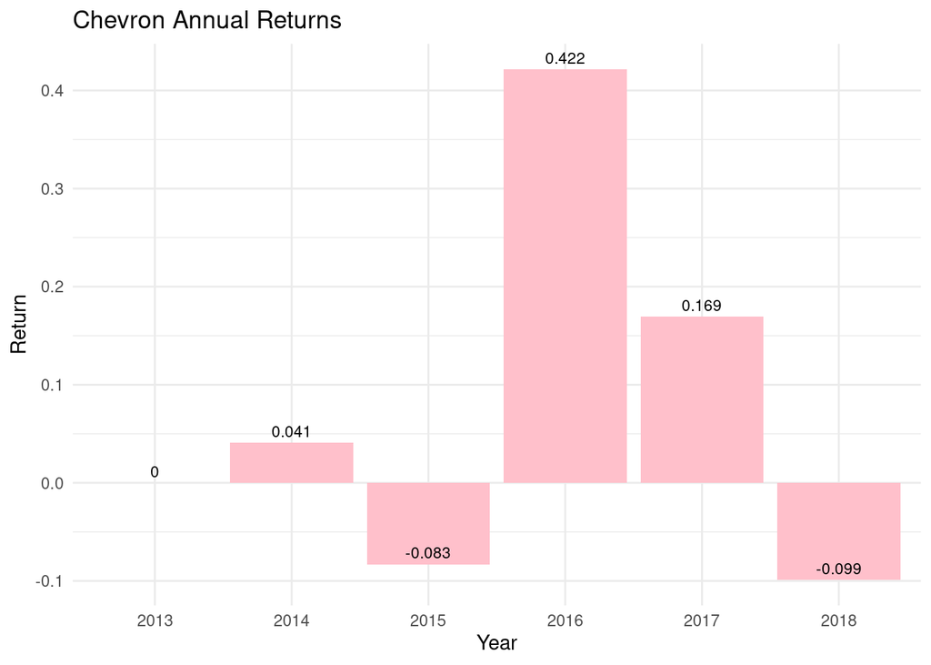

```r
DJ_panel %>%
  filter(TickerSecurity == "CVX", !is.na(TotalReturnIndex)) %>%
  group_by(Year = year(DateEffective)) %>%
  summarise(r = (last(TotalReturnIndex) - first(TotalReturnIndex)) / first(TotalReturnIndex)) %>%
  ggplot(aes(factor(Year), r)) +
  geom_col(fill = "pink") +
  geom_text(aes(label = round(r, 3)), vjust = -0.5, size = 3) +
  labs(title = "Chevron Annual Returns", x = "Year", y = "Return") +
  theme_minimal()
```

**Analysis follow up:** Which year in the dataset was the best returns for Chevron?

From the bar chart, the best year for Chevron’s returns was 2016, with a return of approximately 0.422 (or 42.2%). This is clearly the highest annual return in the dataset shown, significantly outperforming all other years.

### Question 4

4. **(15 points)** - You made an investment in Goldman Sachs (`SecurityTicker` == ‘GS’) at the closing price on the first month available in the dataset and had purchased 1000 shares. How much of an investment was this?

**Question 04, Student**

```r
DJ_panel %>%
  filter(TickerSecurity == "GS") %>%
  arrange(DateEffective) %>%
  slice(1) %>%
  mutate(
    Shares = 1000,
    Investment_Cost = Close_ * Shares) %>%
  select(DateEffective, Close_ , Shares, Investment_Cost, Weight) %>% gt()
```

| DateEffective | Close_ | Shares | Investment_Cost | Weight |
| --- | --- | --- | --- | --- |
| 2013-12-31 | 177.26 | 1000 | 177260 | 6.867335 |

**Analysis follow up:** At the begining of the month selected what had the weight of Goldman Sachs been within the index?

The investment in Goldman Sachs (GS) was made on 2013-12-31, the earliest date available in the dataset. The closing price of GS on that day was $177.26, and purchasing 1000 shares would have cost $177,260 in total. On the same date, Goldman Sachs held a weight of 6.867335% in the Dow Jones Index, indicating its relative influence on the index’s movements at that time.

### Question 5

5. **(15 points)** - You created a portfolio with 60% GS, 25% GE and 15% HD at the end of the first month in the dataset. Use the Total Return Index field to calculate one month forward (for holding the portfolio over the next month) return for the portfolio.

**Question 05, Student**

```r
wts <- tibble(TickerSecurity = c("GS", "GE", "HD"), Weight = c(0.6, 0.25, 0.15))
d1 <- floor_date(min(DJ_panel$DateEffective, na.rm = TRUE), "month") %m+% months(1) - 1
d2 <- d1 %m+% months(1)

DJ_panel %>%
  filter(TickerSecurity %in% wts$TickerSecurity, DateEffective %in% c(d1, d2)) %>%
  select(TickerSecurity, DateEffective, TRI = TotalReturnIndex) %>%
  pivot_wider(names_from = DateEffective, values_from = TRI) %>%
  rename(start = 2, end = 3) %>%
  mutate(Return = (end - start) / start) %>%
  left_join(wts, by = "TickerSecurity") %>%
  summarise(Portfolio_Return = sum(Return * Weight, na.rm = TRUE)) %>% gt()
```

| Portfolio_Return |
| --- |
| 0.08760372 |

**Analysis follow up:** Explain how you used the Total Return Index to calculate the individual security’s return.

To get my portfolio return as 8.76%, I used the Total Return Index values at two specific points: the end of the first month in the dataset and one month later. The Total Return Index accounts for both price changes and dividends, making it ideal for capturing the full return. I took the difference between the index value at the end of the second month and the value at the end of the first month, then divided it by the first month’s value. This gave the percentage return for each security over that one-month period.

## Session Info

```r
date()
```

```
[1] "Sun Mar 23 17:56:38 2025"
```

```r
Sys.getenv()
```

[output not shown]

[output cut: 79 more lines]

[output not shown]